# MyFun

Li Chen 20023

2020-12-20

```r
library(StatComp20023)
```

# Vignette for my functions

## Sequentially and iteratively reweighted squares algorithm for sparse recovery

The algorithm was proposed by Jinchi Lv and Yingying Fan (Lv and Fan 2009)

Consider the linear equation
$$y = X \beta$$
Our aim is to find the minimum $L_0$ (sparsest possible) solution to the linear equation, which is not an easy task when the matrix $X'X$ is singular or close to singular. Here we assume the identifiability of $\beta_0$, in the sense that the equation $X\beta_0 = X\beta, \beta \in R^p$ entails either $\beta = \beta_0$ or ${||\beta||}_0 > {||\beta_0||}_0$.

Lv and Fan propose an equivalence of sparse recovery to
$$\begin{array}{ll}
\min & \sum_{j=1}^{p} \rho_a \left(\left|\beta_{j}\right|\right) \\
\text { s.t. } & \mathbf{y}=\mathbf{X} \boldsymbol{\beta}
\end{array}$$
under some mild conditions, where

$$\begin{equation}
\rho_{a}(t)=\left\{\begin{array}{ll}
\frac{(a+1) t}{a+t}=\left(\frac{t}{a+t}\right) I(t \neq 0)+\left(\frac{a}{a+t}\right) t, & a \in(0, \infty) \\
I(t \neq 0), & a=0 \\
t, & a=\infty
\end{array}\right.
\end{equation}$$

Replace the $\rho$-regularization problem by a weighted $\ell_{2}$ penalty $\rho(\boldsymbol{\beta})=\boldsymbol{\beta}^{T} D^{-1} \boldsymbol{\beta},$ where the $j$-th diagonal element of the diagonal matrix $D^{-1}$ is $d_{j}^{-1}=\rho_{a}\left(\left|\beta_{j}\right|\right) / \beta_{j}^{2}, j=1, \ldots, p .$ Then the minimization problem
$$\begin{array}{ll}
\min & \sum_{j=1}^{p} \rho_{a}\left(\left|\beta_{j}\right|\right)=\boldsymbol{\beta}^{T} D^{-1} \boldsymbol{\beta} \\
\text { s.t. } & \mathbf{y}=\mathbf{X} \boldsymbol{\beta}
\end{array}$$
has explicit solution
$$\beta^{*}=D^{1 / 2}\left(D^{1 / 2} \mathbf{X}^{T} \mathbf{X} D^{1 / 2}\right)^{+} D^{1 / 2} \mathbf{X}^{T} \mathbf{y}=D \mathbf{X}^{T}\left(\mathbf{X} D \mathbf{X}^{T}\right)^{+} \mathbf{y}$$
From this, the sequentially and iteratively reweighted squares (SIRS) algorithm is proposed for solving sparse recovery problem with $\rho_{a}$ penalty.

### Algorithm 1. SIRS

**Input**: sparsity level $S,$ the number of iterations $L,$ the number of sequential steps $M \leq S$ and $\epsilon \in(0,1)$

**Step 1** Set $k=0$

**Step 2** Initialize $\beta^{(0)}=1$ and set $\ell=1$.

**Step 3** $\operatorname{Set} \beta^{(\ell)} \leftarrow D \mathrm{X}^{T}\left(\mathrm{X} D \mathrm{X}^{T}\right)^{+} \mathrm{y}$ with $D=D\left(\beta^{(\ell-1)}\right)$ and $\ell \leftarrow \ell+1$

**Step 4** Repeat step 3 until convergence or $\ell=L+1 .$ Denote the resulting vector as $\tilde{\boldsymbol{\beta}}$

**Step 5** If $\|\tilde{\beta}\|_{0} \leq S,$ stop and return $\tilde{\beta}$. Otherwise, set $k \leftarrow k+1$ and repeat steps $2-4$ with $\beta^{(0)}=I\left(|\tilde{\beta}| \geq \gamma_{(k)}\right)+\epsilon I\left(|\tilde{\beta}|<\gamma_{(k)}\right)$ and $\gamma_{(k)}$ the $k$ th largest component of $|\tilde{\boldsymbol{\beta}}|,$ until stop or $k=M .$ Return $\tilde{\boldsymbol{\beta}}$.

Some proerties of this algorithm have been proven, such as

**1** If $\lim _{\ell \rightarrow \infty} \boldsymbol{\beta}^{(\ell)}$ exists, then it is a fixed point of the functional $\mathcal{F}: \mathscr{A} \rightarrow \mathscr{A}$

$$\mathcal{F}(\boldsymbol{\gamma})=\underset{\boldsymbol{\beta} \in \mathcal{A}}{\arg \min } \boldsymbol{\beta}^{T} \boldsymbol{\Gamma}(\boldsymbol{\gamma}) \boldsymbol{\beta}$$
where $\mathcal{A}=\left\{\boldsymbol{\beta} \in \mathbf{R}^{p}: \mathbf{y}=\mathbf{X} \boldsymbol{\beta}\right\}$ and $\boldsymbol{\Gamma}(\boldsymbol{\gamma})$ denotes $\boldsymbol{\Gamma}$ given by $\mathbf{D}=\mathbf{D}(\boldsymbol{\gamma})$

**2** $\beta_{0}$ is always a fixed point of the functional $\mathcal{F}$.

**3** Assume that $p>n, \operatorname{spark}(\mathbf{X})=n+1$ and $\left\|\boldsymbol{\beta}_{0}\right\|_{0}<(n+1) / 2$. Then for any fixed point $\boldsymbol{\beta}$ of the functional $\mathcal{F},$ we have $\boldsymbol{\beta}=\boldsymbol{\beta}_{0}$ or $\|\boldsymbol{\beta}\|_{0}>(n+1) / 2$

My function `sirs` implements sparse recovery using the SIRS algorithm described aboved and `simu_sirs_geneartion` generates $X$ and $y$, where $X$ is $n \times p$ matrix with each row $i.i.d.$ from multi-variate normal distribution with a covariance matrix consisting of $1$ in its diagonal and $r$ in other positions, $y$ is the response for $X$ with first $s$ columns as its support and $\beta$ as its non-zero coefficients.

```r
set.seed(0)
s <- 7; n<- 35; p <- 100; r <- 0.1; beta <- c(1,-0.5,0.7,-1.2,-0.9,3,0.55);
data <- simu_sirs_generation(s,n,p,r,beta)
X <- data[[1]]
y <- data[[2]]
a <- 0.5
beta_hat <- sirs(X,y,a)
sum(beta_hat!=0)
```

```
#> [1] 7
```

```r
beta_hat[1:s]
```

```
#> [1]  1.00 -0.50  0.70 -1.20 -0.90  3.00  0.55
```

From the example shown above, the sirs algorithm functions well in sparse recovery.

Actually, to measure the performance of SIRS, a simulation was conducted

```r
as <- c(0,0.05,0.1,0.2,1,2,5)
rs <- c(0,0.2,0.5)
beta <- c(1,-0.5,0.7,-1.2,-0.9,3,0.55)
s <- 7
n <- 35
p <- 1000
p_as <- length(as)
p_rs <- length(rs)
n_data_set <- 100;
success_percent <- matrix(0,p_as,p_rs)

for (i in 1:p_as){
  for (j in 1:p_r){
    a <- as[i]
    r <- rs[j]
    record <- 0
    for (k in 1:n_data_set){
      res <- simu_sirs_generation(s,n,p,r,beta)
      X <- res[[1]]
      y <- res[[2]]
      beta_sirs <- sirs(X,y,a)
      if (identical(beta_sirs[beta_sirs!=0],1:s)){
        record <- record + 1
      }
    }
    success_percent[i,j] <- record / n_data_set
  }
}
```

the results are given below:

|  | r = 0 | r = 0.2 | r = 0.5 |
| --- | --- | --- | --- |
| a = 0 | 0.51 | 0.55 | 0.59 |
| a = 0.05 | 0.73 | 0.57 | 0.53 |
| a = 0.1 | 0.63 | 0.71 | 0.59 |
| a = 0.2 | 0.70 | 0.61 | 0.64 |
| a = 1 | 0.63 | 0.60 | 0.50 |
| a = 2 | 0.51 | 0.45 | 0.36 |
| a = 5 | 0.15 | 0.14 | 0.08 |

In the simulation 1 of SICA paper, Lv and Fan also conducted sparse recovery using lasso and lla and showed superiority of SIRS algorithm.

## An anomaly detection method for monitoring devices in spatial statistics

Fine Particulate matter($PM_{2.5}$) has gained increasing attention due to its adverse health effects to humans. We aggregated a 57-hour data consisting of 2042 AirBoxes around July 23rd to July 24th in 2019 from the Open Data Portal provided by the LASS community (n.d.). The original data is available in this package with name `PMdata_original`.

To ensure data quality for managing a large network sensing system, anomaly detection is crucial. Anomalies can be classified into three main categories:

- AirBoxes with relative higher measurements than those from their neighboring AirBoxes.
- AirBoxes with relative lower measurements than those from their neighboring AirBoxes.
- AirBoxes whose measurements have a higher variation than their neighboring AirBoxes.

A method of automatically monitoring anomalous measurements by utilizing neighboring AirBox information was proposed (Huang et al. 2018) with main procedures shown as follow:

1. Firstly, consider a universal Kriging model with a class of multi-resolution spline basis functions (Tzeng and Huang 2018) as regressors and apply a robust method for parameter estimation.
2. Secondly, Let $\{ {\hat{y}}_{t}(s):s \in D\}$ be the estimated $PM_{2.5}$ map obtained from universal Kriging at time t based on $z_{t} = (z_{t}(s_{1}),\ldots,z_{t}(s_{n}))$ observed at locations $\{s_{1},\ldots,s_{n}\}$, where $t = 1,\ldots,T$. Denote the standardized residuals as follows:
   $$r_{t}\left(s_{i}\right)=\frac{z_{t}\left(s_{i}\right)-\hat{y}_{t}\left(s_{i}\right)}{\hat{\sigma}_{t}\left(s_{i}\right)} ; \quad i=1, \ldots, n, t=1, \ldots, T$$
   where ${{\hat{\sigma}_{t}^2}(s_{i})}$ is an estimator of:
   $${\sigma_{t}}^2 (s_{i})= var(z_{t}(s_{i}) - \hat{y}_{t}(s_{i}))$$
3. Thirdly, we rank the potential unusual AirBoxes according to the root mean square error(RMSE):
   $$\operatorname{RMSE}_{i}=\left\{\frac{1}{\left|T_{i}\right|} \sum_{t \in T_{i}}\left(r_{t}\left(\boldsymbol{s}_{i}\right)\right)^{2}\right\}^{1 / 2}$$
   and we can further decompose $RMSE_{i}$ in terms of squared bias $b_{i}^2$ and variance $V_{i}$ as follows:
   $$\begin{align*}
   \mathrm{RMSE}_{i} &=\left(b_{i}^{2}+V_{i}\right)^{1 / 2} \\ b_{i} &=\frac{1}{\left|T_{i}\right|} \sum_{t \in T_{i}} r_{t}\left(\boldsymbol{s}_{i}\right), \\ V_{i} &=\frac{1}{\left|T_{i}\right|} \sum_{t \in T_{i}}\left\{r_{t}\left(\boldsymbol{s}_{i}\right)-\frac{1}{\left|T_{i}\right|} \sum_{t \in T_{i}} r_{t}\left(\boldsymbol{s}_{i}\right)\right\}^{2}
   \end{align*}$$
4. Lastly, we can classify the AirBoxes with high $RMSEs$ into three groups separated by the upper and lower control limits according to $b_{i}$.
   - An AirBox with $b_{i}$ larger than the b threshold implies that its average standardized residual value is above the upper control limit.
   - An AirBox with $b_{i}$ smaller than minus b threshold implies that its average standardized residual value is below the lower control limit.
   - An airBox with high $RMSE_{i}$ but with $b_{i} \in (\text{minus b threshold},\text{b threshold})$ tends to have a higher variation than its neighboring AirBoxes.

To illustrate the usage of my code, here are some examples.

```r
data(PMdata_original)
```

Function `geo_anomaly` implement anomaly detection using the method described above.

```r
K <- 100; b_threshold <- 3; Rmse_threshold <- 4;
l <- geo_anomaly(PMdata_original,K,b_threshold,Rmse_threshold)
```

Actually, for ease of creating vignette, I put the result of applying `geo_anomaly` to PMdata_original as “l” in the package.

```r
library(ggplot2)
data(l)
```

```r
PMdata_type <- cbind(PMdata_original,type = rep(1,nrow(PMdata_original)))
for (i in 1:nrow(PMdata_original)){
  if (PMdata_type[i,1] %in% l[[1]])
    PMdata_type$type[i] <- 2
  else{
    if (PMdata_type[i,1] %in% l[[2]])
      PMdata_type$type[i] <- 3
    else{
      if(PMdata_type[i,1] %in% l[[3]])
        PMdata_type$type[i] <- 4
    }
  }
}
PMdata_type$type <- as.factor(PMdata_type$type)
```

Here are the locations of Airboxes with type 1 denoting normal Airboxes, type 2 denoting Airboxes with relatively high measurements than those of their neighboring Airboxes, type 3 denoting Airboxes with relatively low measurements than those of their neighboring Airboxes, type 4 denoting malfunctioned Airboxes or Airboxes in complicate environments.

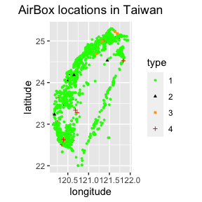

```r
ggplot(PMdata_type,aes(x=lon,y=lat,color=type,shape=type))+
  scale_color_manual(values = c("green","black","orange","red"))+
  geom_point(size=1)+
  coord_equal(ratio=1)+
  labs(title="AirBox locations in Taiwan",x="longitude",y="latitude")+
  theme(plot.title = element_text(hjust=0.5))
```

To better clarify the locations of Airboxes in different types, we plot them in different grids.

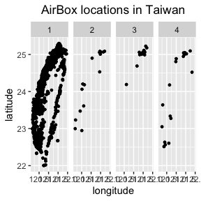

```r
ggplot(PMdata_type,aes(x=lon,y=lat))+
  geom_point(size=1)+
  facet_grid(.~type)+
  labs(title="AirBox locations in Taiwan",x="longitude",y="latitude")+
  theme(plot.title = element_text(hjust=0.5))
```

As is shown in the figure as follow, 18 of 2042 Airboxes are classified in type 2, 18 of 2042 Airboxes are classified in type 3 and 21 of 2042 Airboxes are classified in type 4.

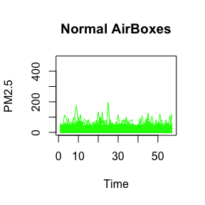

```r
PMdata <- PMdata_original[,-1]
plot(c(1,57),c(0,480),type = "n",xlab="Time",ylab="PM2.5",main = "Normal AirBoxes")
ccolor <- c("green","blue","black","red")
for (i in (1:(nrow(PMdata)))){
  if (PMdata_type[i,]$type == 1)
    lines(1:(ncol(PMdata)-2),PMdata[i,-c(1,2)],col=ccolor[PMdata_type[i,]$type])
}
```

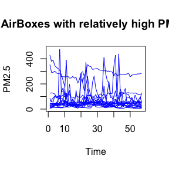

```r
plot(c(1,57),c(0,480),type = "n",xlab="Time",ylab="PM2.5",main = "AirBoxes with relatively high PM2.5")
ccolor <- c("green","blue","black","red")
for (i in (1:(nrow(PMdata)))){
  if (PMdata_type[i,]$type == 2)
    lines(1:(ncol(PMdata)-2),PMdata[i,-c(1,2)],col=ccolor[PMdata_type[i,]$type])
}
```

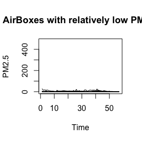

```r
plot(c(1,57),c(0,480),type = "n",xlab="Time",ylab="PM2.5",main = "AirBoxes with relatively low PM2.5")
ccolor <- c("green","blue","black","red")
for (i in (1:(nrow(PMdata)))){
  if (PMdata_type[i,]$type == 3)
    lines(1:(ncol(PMdata)-2),PMdata[i,-c(1,2)],col=ccolor[PMdata_type[i,]$type])
}
```

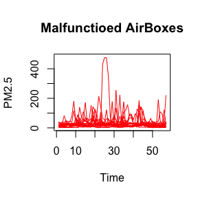

```r
plot(c(1,57),c(0,480),type = "n",xlab="Time",ylab="PM2.5",main = "Malfunctioed AirBoxes")
ccolor <- c("green","blue","black","red")
for (i in (1:(nrow(PMdata)))){
  if (PMdata_type[i,]$type == 4)
    lines(1:(ncol(PMdata)-2),PMdata[i,-c(1,2)],col=ccolor[PMdata_type[i,]$type])
}
```

The method should have done a good job in detecting anomalous devices.

## References

Huang, G., L.-J. Chen, W.-H. Hwang, S. Tzeng, and H.-C. Huang. 2018. “Real-Time Pm2.5 Mapping and Anomaly Detection from Airboxes in Taiwan.” *Environmetrics* 29 (8): e2357.

Lv, Jinchi, and Yingying Fan. 2009. “A Unified Approach to Model Selection and Sparse Recovery Using Regularized Least Squares.” *Ann. Statist.* 37 (6A): 3498–3528.

Tzeng, ShengLi, and Hsin-Cheng Huang. 2018. “Resolution Adaptive Fixed Rank Kriging.” *Technometrics* 60 (2): 198–208.

n.d. https://pm25.lass-net.org.